# Recall performance for objects outside the rooms

# 1 Visual inspection of the data

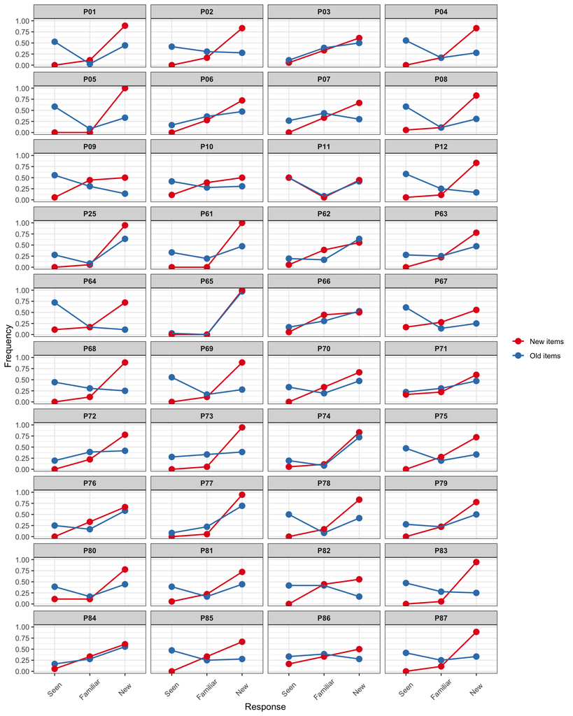

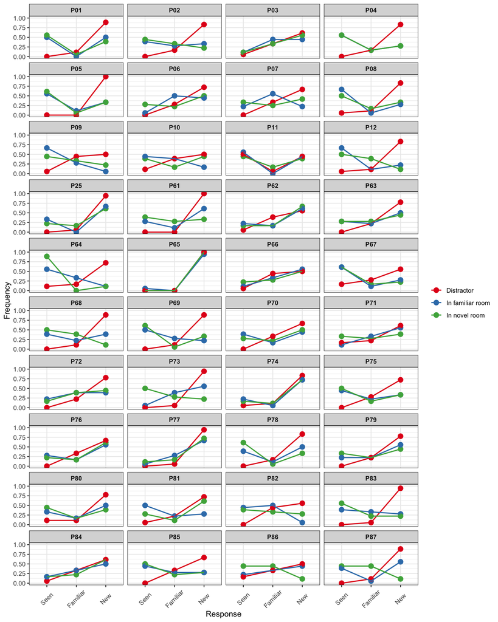

# 2 Novelty Benefits

## 2.1 Check the data

- **Is there any corrected hit rate < 0?**
  - There are 2 negative value out of a total of 80 values.

```
##    SubjectNo    Group MeanCurRt  MeanDur     SFHit      SHit     SrcHit
## 1:       P11    Novel  4.666667      NaN 0.6111111 0.4444444 0.11111111
## 2:       P71 Familiar  2.000000 25.45671 0.4444444 0.1111111 0.05555556
##      SFFalse    SFalse  SrcFalse      SFAcc        SAcc      SrcAcc
## 1: 0.5555556 0.5000000 0.1851852 0.05555556 -0.05555556 -0.07407407
## 2: 0.3888889 0.1666667 0.1481481 0.05555556 -0.05555556 -0.09259259
```

## 2.2 Compare mean accuracy between *novel* and *familiar* rooms

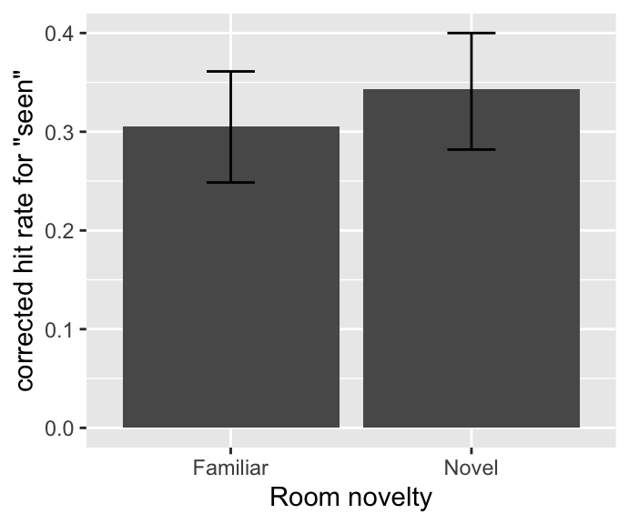

Figure1. Mean accuracy for item memory respectively for Familiar and Novel rooms.

```
##       Group      Mean        SD  N
## 1: Familiar 0.3055556 0.1853276 40
## 2:    Novel 0.3430556 0.1886657 40
```

```
##
##  Paired t-test
##
## data:  SAcc by Group
## t = -1.6903, df = 39, p-value = 0.09895
## alternative hypothesis: true difference in means is not equal to 0
## 95 percent confidence interval:
##  -0.082374341  0.007374341
## sample estimates:
## mean of the differences
##                 -0.0375
```

## 2.3 Any difference between *Early* and *Later* object groups?

### 2.3.1 Check the data

- **Is there any corrected hit rate < 0?**
  - There are 4 negative values out of a total of 160 values.

```
##    SubjectNo    Group ObjOrdGrp MeanCurRt  MeanDur     SFHit      SHit
## 1:       P03 Familiar     Early  3.333333      NaN 0.5555556 0.0000000
## 2:       P11    Novel     Early  4.666667      NaN 0.4444444 0.3333333
## 3:       P71 Familiar     Early  2.000000 25.45671 0.2222222 0.0000000
## 4:       P86 Familiar     Early  3.000000 26.59735 0.4444444 0.1111111
##       SrcHit   SFFalse     SFalse  SrcFalse       SFAcc        SAcc
## 1: 0.3333333 0.3888889 0.05555556 0.1296296  0.16666667 -0.05555556
## 2: 0.0000000 0.5555556 0.50000000 0.1851852 -0.11111111 -0.16666667
## 3: 0.1111111 0.3888889 0.16666667 0.1481481 -0.16666667 -0.16666667
## 4: 0.0000000 0.5000000 0.16666667 0.1666667 -0.05555556 -0.05555556
##         SrcAcc
## 1:  0.20370370
## 2: -0.18518519
## 3: -0.03703704
## 4: -0.16666667
```

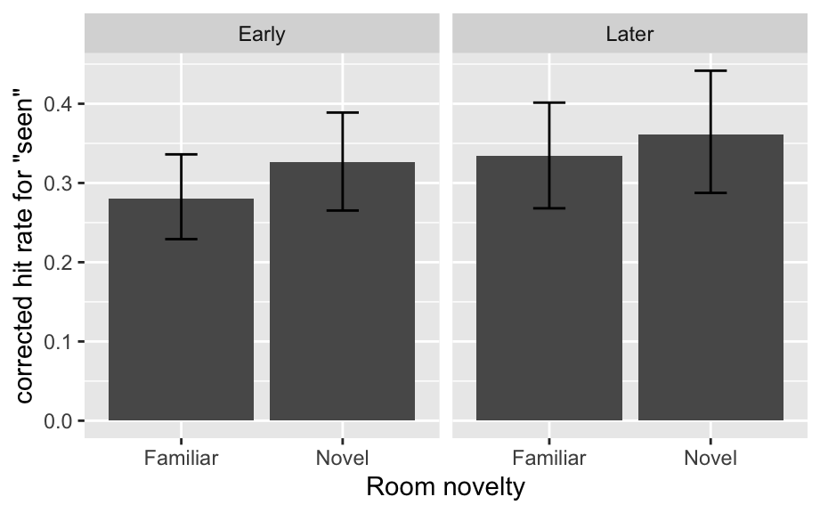

```
##       Group ObjOrdGrp      Mean        SD  N
## 1: Familiar     Early 0.2805556 0.1886919 40
## 2:    Novel     Early 0.3263889 0.2098355 40
## 3:    Novel     Later 0.3611111 0.2387050 40
## 4: Familiar     Later 0.3347222 0.2121982 40
```

```
## $ANOVA
##            Effect DFn DFd         F          p p<.05          ges
## 2           Group   1  39 2.7112299 0.10768009       0.0073092144
## 3       ObjOrdGrp   1  39 4.2055602 0.04705391     * 0.0110304414
## 4 Group:ObjOrdGrp   1  39 0.1448715 0.70555069       0.0005334262
```

# 3 Curiosity Enhancement

## 3.1 Check the data

### 3.1.1 Is there any corrected hit rate < 0?

#### 3.1.1.1 For the data per room

- There are 20 negative value out of a total of 239 values.

```
##     SubjectNo     Context    Group CurRating RoomOrder Duration     SFHit
##  1:       P03     Bedroom Familiar         5     First       NA 0.3333333
##  2:       P03         Gym Familiar         1    Second       NA 0.3333333
##  3:       P03     Library    Novel         7     First       NA 0.3333333
##  4:       P03  LivingRoom    Novel         7    Second       NA 0.1666667
##  5:       P11   Classroom Familiar         5     First       NA 0.3333333
##  6:       P11         Gym Familiar         7    Second       NA 0.3333333
##  7:       P11  LivingRoom    Novel         6    Second       NA 0.3333333
##  8:       P62   Classroom    Novel         5    Second 26.51928 0.1666667
##  9:       P62     Library Familiar         4     First 23.52452 0.3333333
## 10:       P66     Bedroom    Novel         5     First 14.86723 0.3333333
## 11:       P66     Library Familiar         2    Second 14.59909 0.1666667
## 12:       P66 StorageRoom Familiar         1    Second 13.87033 0.3333333
## 13:       P71  LivingRoom Familiar         3     First 23.99681 0.1666667
## 14:       P71 StorageRoom Familiar         2    Second 25.45726 0.5000000
```

[output cut: 48 more lines]

#### 3.1.1.2 For the data per curiosity group

- There are 3 negative value for curiosity group (1 ~ 3 and 5 ~ 7) out of a total of 78 values.

```
##    SubjectNo CurGrp  MeanDur     SFHit      SHit     SrcHit   SFFalse
## 1:       P03   High      NaN 0.2777778 0.0000000 0.05555556 0.3888889
## 2:       P11   High      NaN 0.3333333 0.2222222 0.11111111 0.5555556
## 3:       P71    Low 25.45671 0.4444444 0.1111111 0.05555556 0.3888889
##        SFalse  SrcFalse       SFAcc        SAcc      SrcAcc
## 1: 0.05555556 0.1296296 -0.11111111 -0.05555556 -0.07407407
## 2: 0.50000000 0.1851852 -0.22222222 -0.27777778 -0.07407407
## 3: 0.16666667 0.1481481  0.05555556 -0.05555556 -0.09259259
```

#### 3.1.1.3 For the data per curiosity group (median)

- There are 3 negative value for curiosity group (median) out of a total of 79 values.

```
##    SubjectNo CurGrpMedian  MeanDur     SFHit      SHit     SrcHit
## 1:       P03         High      NaN 0.2777778 0.0000000 0.05555556
## 2:       P11         High      NaN 0.3333333 0.2222222 0.11111111
## 3:       P71          Low 25.45671 0.4444444 0.1111111 0.05555556
##      SFFalse     SFalse  SrcFalse       SFAcc        SAcc      SrcAcc
## 1: 0.3888889 0.05555556 0.1296296 -0.11111111 -0.05555556 -0.07407407
## 2: 0.5555556 0.50000000 0.1851852 -0.22222222 -0.27777778 -0.07407407
## 3: 0.3888889 0.16666667 0.1481481  0.05555556 -0.05555556 -0.09259259
```

## 3.2 Mean accuracy of item memory as a function of curiosity rating

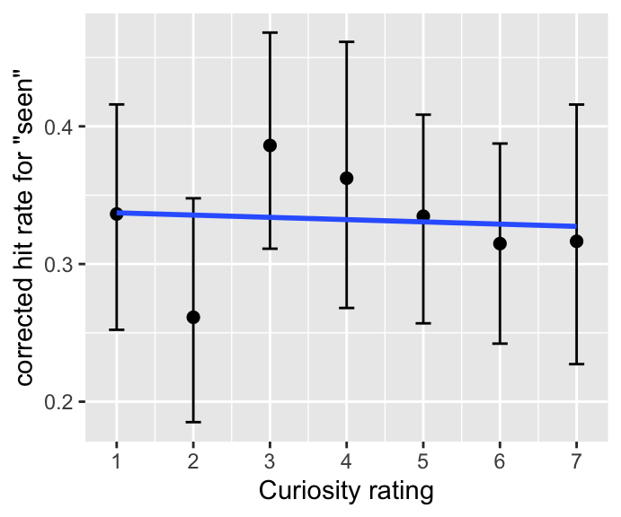

## 3.3 Testing the relationship between mean accuracy of item memory and curiosity rating

Build models with item memory accuracy as $y$ and examine effects of curiosity rating by including it into the model and then comparing the model fits.

- `baseline.rating` is the model with only an intercept, showing no change in item memory as a function of curiosity rating.
- `rating.intercept` is the model with $\small CuriosityRating$ included, showing the effects of curiosity rating.
- `rating.slope` is the model allowing the slope (i.e., relationship between item memory and curiosity rating) varying across participants.

```
##                  Model df        AIC       BIC   logLik   Test     L.Ratio
## baseline.rating      1  3 -11.785172 -1.355781 8.892586
## rating.intercept     2  4  -9.795115  4.110739 8.897557 1 vs 2 0.009942847
## rating.slope         3  6  -5.779468 15.079314 8.889734 2 vs 3 0.015647069
##                  p-value
## baseline.rating
## rating.intercept  0.9206
## rating.slope      0.9922
```

## 3.4 Check the curiosity groups

### 3.4.1 Separate the groups according to the rating

- *High*: curiosity rating > 4
- *Low*: curiosity rating < 4
- For curiosity rating = 4, discarded

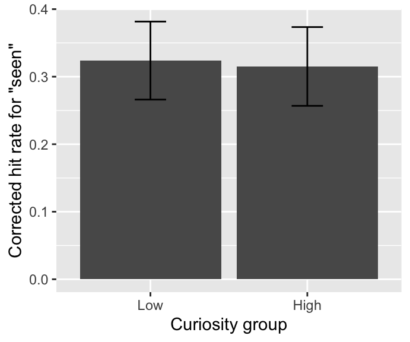

#### 3.4.1.1 Curiosity groups and temporal order of the objects

##### 3.4.1.1.1 Check the data

**Is there any corrected hit rate < 0?**

There are 11 negative values.

```
##     SubjectNo CurGrp ObjOrdGrp     SFHit      SHit    SrcHit   SFFalse
##  1:       P03   <NA>     Early 1.0000000 0.0000000 0.6666667 0.3888889
##  2:       P03   High     Early 0.3333333 0.0000000 0.1111111 0.3888889
##  3:       P03   High     Later 0.2222222 0.0000000 0.0000000 0.3888889
##  4:       P11   High     Later 0.4444444 0.2222222 0.1111111 0.5555556
##  5:       P11   High     Early 0.2222222 0.2222222 0.1111111 0.5555556
##  6:       P62   <NA>     Later 0.6666667 0.0000000 0.0000000 0.4444444
##  7:       P62   <NA>     Early 0.0000000 0.0000000 0.0000000 0.4444444
##  8:       P71    Low     Early 0.2222222 0.0000000 0.1111111 0.3888889
##  9:       P80   High     Early 0.3333333 0.0000000 0.1666667 0.2222222
## 10:       P84   High     Early 0.5000000 0.0000000 0.1666667 0.3888889
## 11:       P86   <NA>     Early 0.6666667 0.0000000 0.0000000 0.5000000
##         SFalse   SrcFalse       SFAcc        SAcc      SrcAcc
##  1: 0.05555556 0.12962963  0.61111111 -0.05555556  0.53703704
##  2: 0.05555556 0.12962963 -0.05555556 -0.05555556 -0.01851852
##  3: 0.05555556 0.12962963 -0.16666667 -0.05555556 -0.12962963
##  4: 0.50000000 0.18518519 -0.11111111 -0.27777778 -0.07407407
##  5: 0.50000000 0.18518519 -0.33333333 -0.27777778 -0.07407407
##  6: 0.05555556 0.14814815  0.22222222 -0.05555556 -0.14814815
##  7: 0.05555556 0.14814815 -0.44444444 -0.05555556 -0.14814815
##  8: 0.16666667 0.14814815 -0.16666667 -0.16666667 -0.03703704
##  9: 0.11111111 0.09259259  0.11111111 -0.11111111  0.07407407
## 10: 0.05555556 0.14814815  0.11111111 -0.05555556  0.01851852
## 11: 0.16666667 0.16666667  0.16666667 -0.16666667 -0.16666667
```

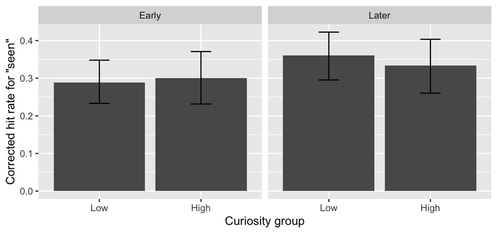

```
##    CurGrp ObjOrdGrp      Mean        SD  N
## 1:    Low     Early 0.2887427 0.1910951 38
## 2:   <NA>     Early 0.3660131 0.3239768 17
## 3:   <NA>     Later 0.3709150 0.3015746 17
## 4:   High     Early 0.3008333 0.2191871 40
## 5:   High     Later 0.3340278 0.2340587 40
## 6:    Low     Later 0.3603801 0.2085196 38
```

```
##           Model df       AIC       BIC   logLik   Test  L.Ratio p-value
## baseline      1  8 -68.40329 -44.00444 42.20164
## ord.model     2  9 -71.10021 -43.65150 44.55010 1 vs 2 4.696918  0.0302
## cur.model     3 10 -69.12804 -38.62948 44.56402 2 vs 3 0.027836  0.8675
## int.model     4 11 -67.86148 -34.31306 44.93074 3 vs 4 0.733433  0.3918
```

```
## Linear mixed-effects model fit by maximum likelihood
##  Data: outside.hit.rate.item.order.curiosity[!is.na(CurGrp)]
##         AIC       BIC   logLik
##   -67.86148 -34.31306 44.93074
##
## Random effects:
##  Formula: ~1 + CurGrp + ObjOrdGrp | SubjectNo
##  Structure: General positive-definite, Log-Cholesky parametrization
##                StdDev     Corr
## (Intercept)    0.13234550 (Intr) CrGrpH
## CurGrpHigh     0.09591564 -0.032
## ObjOrdGrpLater 0.05169066  0.697 -0.698
## Residual       0.13663772
##
## Fixed effects: SAcc ~ ObjOrdGrp + CurGrp + ObjOrdGrp:CurGrp
##                                 Value  Std.Error  DF   t-value p-value
## (Intercept)                0.28387530 0.03103424 113  9.147164  0.0000
## ObjOrdGrpLater             0.07110229 0.03286616 113  2.163389  0.0326
## CurGrpHigh                 0.01695803 0.03505417 113  0.483766  0.6295
## ObjOrdGrpLater:CurGrpHigh -0.03790785 0.04438116 113 -0.854143  0.3948
##  Correlation:
##                           (Intr) ObjOGL CrGrpH
## ObjOrdGrpLater            -0.370
## CurGrpHigh                -0.482  0.357
## ObjOrdGrpLater:CurGrpHigh  0.363 -0.694 -0.629
##
## Standardized Within-Group Residuals:
##         Min          Q1         Med          Q3         Max
## -2.16499937 -0.61948272 -0.01843298  0.56607249  2.30769940
##
## Number of Observations: 156
## Number of Groups: 40
```

##### 3.4.1.1.2 *Post hoc*

```
##
##   Simultaneous Tests for General Linear Hypotheses
##
## Fit: lme.formula(fixed = SAcc ~ ObjOrdGrp + CurGrp + ObjOrdGrp:CurGrp,
##     data = outside.hit.rate.item.order.curiosity[!is.na(CurGrp)],
##     random = ~1 + CurGrp + ObjOrdGrp | SubjectNo, method = "ML",
##     na.action = na.exclude, control = list(msMaxIter = 500, opt = "optim",
##         msVerbose = FALSE))
##
## Linear Hypotheses:
##                          Estimate Std. Error z value Pr(>|z|)
## Early: High vs. Low == 0  0.01696    0.03460   0.490    0.624
## Late:  High vs. Low == 0 -0.02095    0.03477  -0.603    0.547
## (Adjusted p values reported -- none method)
```

### 3.4.2 Separate the groups according to the median rating of each participant

- *High*: curiosity rating > median of the participant
- *Low*: curiosity rating < median of the participant

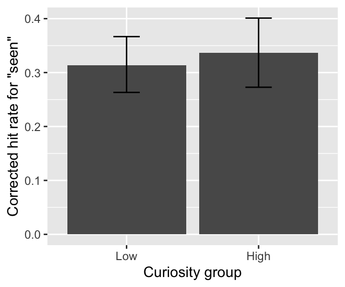

```
## Linear mixed-effects model fit by maximum likelihood
##  Data: outside.hit.rate.curiosity.group.median
##         AIC       BIC   logLik
##   -54.19242 -39.97573 33.09621
##
## Random effects:
##  Formula: ~1 + CurGrpMedian | SubjectNo
##  Structure: General positive-definite, Log-Cholesky parametrization
##                  StdDev     Corr
## (Intercept)      0.15251323 (Intr)
## CurGrpMedianHigh 0.12858166 -0.075
## Residual         0.06343237
##
## Fixed effects: SAcc ~ CurGrpMedian
##                       Value  Std.Error DF   t-value p-value
## (Intercept)      0.31388889 0.02645403 39 11.865448  0.0000
## CurGrpMedianHigh 0.01927954 0.02541481 38  0.758595  0.4528
##  Correlation:
##                  (Intr)
## CurGrpMedianHigh -0.21
##
## Standardized Within-Group Residuals:
##         Min          Q1         Med          Q3         Max
## -1.40559783 -0.33367188 -0.01177138  0.28868716  1.08280754
##
## Number of Observations: 79
## Number of Groups: 40
```

#### 3.4.2.1 Curiosity groups and temporal order of the objects

##### 3.4.2.1.1 Check the data

- **Is there any corrected hit rate < 0?**
  - There are 6 negative values out of a total of 168 values.

```
##    SubjectNo CurGrpMedian ObjOrdGrp     SFHit      SHit    SrcHit
## 1:       P03         High     Early 0.3333333 0.0000000 0.1111111
## 2:       P03         High     Later 0.2222222 0.0000000 0.0000000
## 3:       P11         High     Later 0.4444444 0.2222222 0.1111111
## 4:       P11         High     Early 0.2222222 0.2222222 0.1111111
## 5:       P71          Low     Early 0.2222222 0.0000000 0.1111111
## 6:       P86          Low     Early 0.4444444 0.1111111 0.0000000
##      SFFalse     SFalse  SrcFalse       SFAcc        SAcc      SrcAcc
## 1: 0.3888889 0.05555556 0.1296296 -0.05555556 -0.05555556 -0.01851852
## 2: 0.3888889 0.05555556 0.1296296 -0.16666667 -0.05555556 -0.12962963
## 3: 0.5555556 0.50000000 0.1851852 -0.11111111 -0.27777778 -0.07407407
## 4: 0.5555556 0.50000000 0.1851852 -0.33333333 -0.27777778 -0.07407407
## 5: 0.3888889 0.16666667 0.1481481 -0.16666667 -0.16666667 -0.03703704
## 6: 0.5000000 0.16666667 0.1666667 -0.05555556 -0.05555556 -0.16666667
```

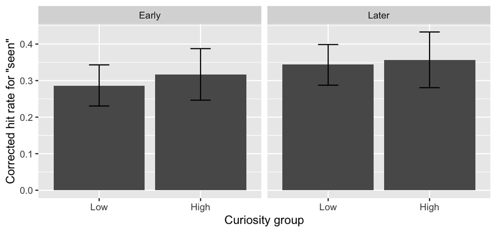

```
##    CurGrpMedian ObjOrdGrp      Mean        SD  N
## 1:          Low     Early 0.2861111 0.1922650 40
## 2:          Low     Later 0.3444444 0.1849856 40
## 3:         High     Early 0.3162393 0.2230081 39
## 4:         High     Later 0.3561254 0.2544975 39
## 5:         <NA>     Early 0.3333333 0.1178511  5
## 6:         <NA>     Later 0.2500000 0.2500000  5
```

```
##           Model df       AIC       BIC   logLik   Test  L.Ratio p-value
## baseline      1  8 -67.03688 -42.53612 41.51844
## ord.model     2  9 -69.31076 -41.74740 43.65538 1 vs 2 4.273878  0.0387
## cur.model     3 10 -67.76545 -37.13950 43.88273 2 vs 3 0.454695  0.5001
## int.model     4 11 -65.92048 -32.23193 43.96024 3 vs 4 0.155026  0.6938
```

```
## Linear mixed-effects model fit by maximum likelihood
##  Data: outside.hit.rate.item.order.curiosity.median[!is.na(CurGrpMedian)]
##         AIC       BIC   logLik
##   -65.92048 -32.23193 43.96024
##
## Random effects:
##  Formula: ~1 + CurGrpMedian + ObjOrdGrp | SubjectNo
##  Structure: General positive-definite, Log-Cholesky parametrization
##                  StdDev     Corr
## (Intercept)      0.12025915 (Intr) CrGrMH
## CurGrpMedianHigh 0.07389664  0.596
## ObjOrdGrpLater   0.05037129  0.297 -0.544
## Residual         0.14368453
##
## Fixed effects: SAcc ~ ObjOrdGrp + CurGrpMedian + ObjOrdGrp:CurGrpMedian
##                                       Value  Std.Error  DF   t-value
## (Intercept)                      0.28611111 0.03000808 115  9.534470
## ObjOrdGrpLater                   0.05833333 0.03352840 115  1.739819
## CurGrpMedianHigh                 0.02695847 0.03497668 115  0.770756
## ObjOrdGrpLater:CurGrpMedianHigh -0.01850017 0.04633220 115 -0.399294
##                                 p-value
## (Intercept)                      0.0000
## ObjOrdGrpLater                   0.0846
## CurGrpMedianHigh                 0.4424
## ObjOrdGrpLater:CurGrpMedianHigh  0.6904
##  Correlation:
##                                 (Intr) ObjOGL CrGrMH
## ObjOrdGrpLater                  -0.480
## CurGrpMedianHigh                -0.375  0.407
## ObjOrdGrpLater:CurGrpMedianHigh  0.381 -0.682 -0.663
##
## Standardized Within-Group Residuals:
##         Min          Q1         Med          Q3         Max
## -2.07206976 -0.64497965 -0.01454417  0.58296000  2.08887263
##
## Number of Observations: 158
## Number of Groups: 40
```

##### 3.4.2.1.2 *Post hoc*

```
##
##   Simultaneous Tests for General Linear Hypotheses
##
## Fit: lme.formula(fixed = SAcc ~ ObjOrdGrp + CurGrpMedian + ObjOrdGrp:CurGrpMedian,
##     data = outside.hit.rate.item.order.curiosity.median[!is.na(CurGrpMedian)],
##     random = ~1 + CurGrpMedian + ObjOrdGrp | SubjectNo, method = "ML",
##     na.action = na.exclude, control = list(msMaxIter = 500, opt = "optim",
##         msVerbose = FALSE))
##
## Linear Hypotheses:
##                          Estimate Std. Error z value Pr(>|z|)
## Early: High vs. Low == 0 0.026958   0.034531   0.781    0.435
## Late:  High vs. Low == 0 0.008458   0.034507   0.245    0.806
## (Adjusted p values reported -- none method)
```